# Homework 1

Author

Kevin Sanford

Published

October 16, 2024

# Instructions

- This problem set contains 2 exercises in total.
- **You may only use functions from Base R to complete the exercises**. Email Dr. Landeros (`alandero@ucr.edu`) if you have any doubts.
- Check the Canvas Discussion section for updates.

# Background

Many problems in statistics are challenging precisely because at least one key distribution is either unknown or unavailable. Otherwise, many statistics and quantities of interest easy to calculate. We exploit this fact in constructing a data structure for *approximating* various statistics of a data stream.

These two exercises problem guides you in constructing an *expanding histogram* that you can leverage in calculating quantiles. The idea is simple:

1. A user specifies the number of bins $b$ which **must** be even. This information is used to construct $b-1$ *left-closed* bins and $1$ *closed* bin (the rightmost one):

   ```
   [a, b), [b, c), [c, d), [d, e]
   ```

   This numbers $a$, $b$, $c$, $d$, and $e$ are the *edges*.
2. Now suppose we start with the following bin counts:

   ```
   |1|2|5|3|
   ```

   where the extreme edges are $a$ and $e$.
3. We observe a data point $y$ and so we must update the histogram. There are 3 cases to consider:
   - **Case:** $a \le y \le b$: The point lies inside the current limits of the histogram, so we simply find the bin it belongs to.

     ```
        *
        ↓
     |1|2|5|3|   --->   |1|3|5|3|
     ```

   - **Case:** $y > b$: The point lies outside (to the right) of bin edges.

     ```
     |1|2|5|3|       *
     ```

     We expand each bin to the right by doubling the edges. Adjacent bins merge with their neighbors to the right. Multiple expansions (doublings) may be required to cover the data:

     ```
     |1|2|5|3|       *
      \ / \ / \ / \ /
     | 3 | 8 | 0 | 1 |
     ```

   - **Case:** $y < a$: This case is symmetric to the previous case, except the histogram expands to the left.
4. Given our histogram and a probability $p \in [0,1]$, we perform a *search* to find $x$ such that $\Pr(X \le x) \le p$. The value $x$ is an approximation of the target quantile.

This exercise was inspired by Josh Day’s and Hua Zhou’s software package, OnlineStats.jl:

> Day J, Zhou H (2020). OnlineStats.jl: A Julia package for statistics on data streams. *Journal of Open Source Software*, 5(46), 1816, doi: 10.21105/joss.01816

A few additional remarks:

- While we are not aiming for high performance within R, you should be mindful of how you structure your code.
- We will create our own S3 class to represent an expanding histogram. **We did not discuss S3 classes in lecture, so you do not need to worry about these details.** The exercises will give you a sense of how object-oriented programming works in R’s S3 system, but all the work has been done for you.
- Problem 1 is relatively more challenging than Problem 2.
- Problem 2 implements statistics for the expanding histogram. It is written in a way that allows us to grade it independently of Problem 1, but you can test out the functions on the object you created.

# Problem 1: An expanding histogram

## Representing a histogram

The `hist()` function in R is useful for plotting. In the background, it creates a `"histogram"` class object to fit a histogram to data. We can access this object by passing the `plot = FALSE` option to `hist()`.

**Modify the code chunk below to do the following**:

1. Create a `"histogram"` object fit to the given data, `xdata`, as described above.
2. Save this object to a variable called `myhist`.
3. Display `myhist` in your report.
4. *Below the code chunk*, write down the number of *fields* for this object (do not count the `attr(,"class")` which appears).

Study these fields, and consult `help("hist")` if you need clarification.

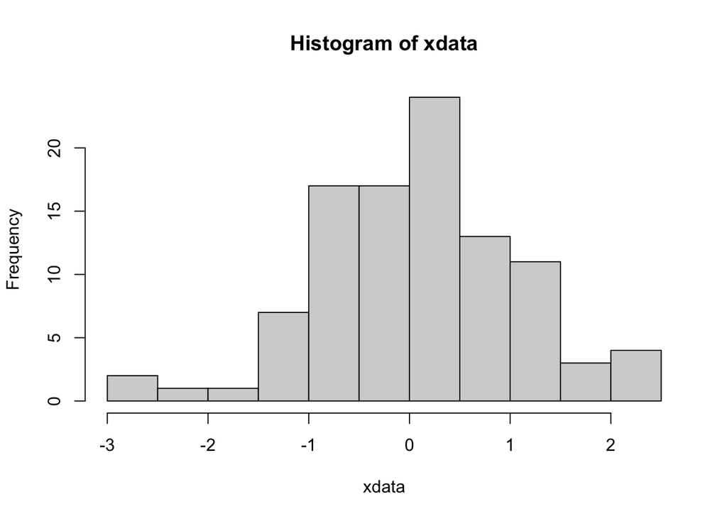

```r
set.seed(206)
xdata <- rnorm(100)
myhist <- hist(xdata, plot = FALSE)
plot(myhist)
```

6 fields exist for this object.

## Writing our own representation

We begin by defining a data structure to represent the expanding histogram. **Complete the function below by filling in the following details**

- The function should accept a single argument, `N`, which represents the number of bins. *Remember than `N` should be even.
- Create a `list` object named `h` to represent the expanding histogram.
- The `list` should have the following fields:
  - `n`, the number of observations used to estimate the histogram.
  - `edges`, a vector of length `N+1` representing the bin edges. Initialize to be `0` everywhere.
  - `counts`, a vector of length `N` representing the counts in each bin. Initialize to be `0` everywhere.

```r
init_expanding_hist <- function (N) {
  edges <- rep(0, N+1)
  counts <- rep(0, N)
  h <- list(n = 0, edges = edges, counts = counts)
  # Make it an S3 class
  class(h) <- "expanding_hist"
  return(h)
}
```

## Finding the correct bin

Now that we’ve outlined an interface, let’s begin by handling placement into bins.

Write a function called `find_bin_index()` that identifies the bin which covers a new observation `y`. *This function will not do any expanding, it only retrieves a number indicating a bin.*

- It should accept two inputs: `edges` and `y`.
- First, handle all the exceptional cases. Two examples (non-exhaustive):
  - If `y` lies to the left of the histogram, the bin index is `0` because it is outside.
  - If `y` is equal to the rightmost *edge*, it is inside the histogram. What is the bin number?
- Lastly, use `findInterval()` to recover the bin index within the histogram.
- This function should return a single number, the bin index.

```r
find_bin_index <- function(edges, y) {
  if (y < edges[1]) {
    return (0)
  }
  if (y > edges[length(edges)]) {
    return (length(edges))
  }
  bin_number <- findInterval(y, edges, rightmost.closed = TRUE)
  return(bin_number)
}
```

## Merging Left

Next we handle the case in which the histogram had to be expanded to cover a new observation.

Write a function called `merge_left()` which merges bin `counts`, *starting from the rightmost bin and moving towards the leftmost one*. This procedure requires three pieces of information:

- `counts`, the bin counts.
- `K`, the number of times the histogram was expanded.
- `M`, the middle bin index ($M = N / 2$ since $N$ is even).
- Return the modified counts.

**Hints**:

- Assume `K` and `M` are given to you and that they are correctly computed.
- What does `K` tell you about the number of required merges? What about `M`?
- This procedure requires two loops.

```r
merge_left <- function(counts, K, M) {
  # define pointer to keep track of elements to merge
  p <- length(counts)
  # define stopping point for merges
  if (K > 0) {
    s <- M + floor(M/(2^K))
  }
  else{
    s <- M
  }
  # merge bins from the right and rewrite into counts
  for (i in length(counts):(s+1)) {
    counts[i] <- counts[p] + counts[p-1]
    # move pointer
    p <- p - 2
  }
  for (i in s:1) {
    counts[i] <- 0
  }
  return(counts)
}
```

## Merging Right

Now we handle the other expansion case.

Write a function called `merge_right()` which merges bin `counts`, *starting from the leftmost bin and moving towards the rightmost one*.

```r
merge_right <- function(counts, K, M) {
  # define pointer to keep track of elements to merge
  p <- 1
  # define stopping point for merges
  s <- ceiling(M/(2^K))
  # merge bins from the left and rewrite into counts
  for (i in 1:s) {
    counts[i] <- counts[p] + counts[p+1]
    # move pointer
    p <- p + 2
  }
  for (i in (s+1):length(counts)) {
    counts[i] <- 0
  }
  return(counts)
}
```

## Expanding the histogram

Next, we combine the merge functions to handle the expansion logic.

Finish implementing the `expand()` function below, using the comments as a guide.

**Hints**:

- This function must check which direction to expand in.
- Expansion should modify the `edges` and `counts` fields only.
- We may not need to modify `h` at all. When is this the case?
- Respect the interface: you do not need additional inputs.
- Note an important invariant: If we expand, exactly one of the extreme edges remains fixed.
- If the current width of the histogram is $0$, then use the new width implied by the update due to the new observation `y`.

```r
# Inputs:
#  h, an expanding_hist object
#  y, a new observation
# Output:
#  h, the expanding_hist object
expand <- function (h, y) {
  # Retrieve extreme edges
  a <- h$edges[1]
  b <- h$edges[length(h$edges)]

  # if the histogram does not need to be expanded, do nothing
  if (y >= a && y <= b) {
    return (h)
  }

  # Compute the width of the histogram
  w <- b - a
  # Calculate the middle bin index, M
  M <- length(h$counts)/2
  # initialize K
  K <- 0
  # calculate new bin width
  binw <- 2*(b-a)/length(h$counts)
  E <- length(h$edges)

  # Expand to the right by finding K such that
  # y <= a + 2^K * w
  if (y > b) {
    while (y > a + (2^K)*w) {
      # expand histogram to the right
      h$counts <- merge_right(h$counts, K, M)
      # apply new bin width
      for (i in 2:E) {
        h$edges[i] <- h$edges[1] + (i-1)*binw
      }
      # double bin width for next iteration
      binw <- binw*2
      K <- K + 1
    }
  }
  # Expand to the left by finding K such that
  # y >= b - 2^K * w
  if (y < a) {
    while (y < b - (2^K)*w) {
      # expand histogram to the left
      h$counts <- merge_left(h$counts, K, M)
      # apply new bin width
      for (i in (E-1):1) {
        h$edges[i] <- h$edges[E] - (E-i)*binw
      }
      # double bin width for next iteration
      binw <- binw*2
      K <- K + 1
    }
  }

  return(h)
}
```

## Putting it all together

Fill in the details for the function below to complete the `fit()` function.

```r
fit <- function (h, y) {
  stopifnot(is.finite(y))
  h$n <- h$n + 1
  N <- length(h$counts)

  if (h$n == 1) {
    # Case: Starting with a fresh histogram.
    # There is only 1 bin, so all edges are equal to each other.
    h$edges <- rep(y,length(h$edges))
    h$counts[N] <- h$counts[N] + 1
  } else if (all(h$edges == h$edges[1])) {
    # Case: We've never expanded before.
    a <- h$edges[1]
    if (y == a) {
      # Don't need to expand.
      h$counts[N] <- h$counts[N] + 1
    } else if (y < a) {
      # Expand once to the left.
      h$edges[1] <- y
      # set equal bin widths between a and y
      h$edges <- seq(y, a, length = length(h$edges))
      h$counts[1] <- 1
    } else {
      # Expand once to the right.
      h$edges[N] <- y
      # set equal bin widths between a and y
      h$edges <- seq(a, y, length = length(h$edges))
      # new value took the count from the old value
      # this statement recounts the old value
      h$counts[1] <- 1
    }
  } else {
    # expand before we update the counts.
    h <- expand(h,y)
    # find where y belongs in the expanded histogram
    yi <- find_bin_index(h$edges,y)
    h$counts[yi] <- h$counts[yi] + 1
  }

  return(h)
}
```

Test your implementation on the following test case. **Do not modify the seed or settings.**

**Expected output**:

- $n = 1000$
- $\min(\text{Edges}) \approx -2.438$
- $\max(\text{Edges}) \approx 13.258$
- $\text{Counts} = {0, 11, 221, 558, 201, 9, 0, 0, 0, 0}$

```r
set.seed(1903)
y <- rnorm(1000, mean = 3, sd = 1.016)
h <- init_expanding_hist(10)
h
```

```
$n
[1] 0

$edges
 [1] 0 0 0 0 0 0 0 0 0 0 0

$counts
 [1] 0 0 0 0 0 0 0 0 0 0

attr(,"class")
[1] "expanding_hist"
```

```r
for (yi in y) {
  h <- fit(h, yi)
}
h
```

```
$n
[1] 1000

$edges
 [1] -2.4381190 -0.8684925  0.7011339  2.2707603  3.8403867  5.4100131
 [7]  6.9796395  8.5492660 10.1188924 11.6885188 13.2581452

$counts
 [1]   0  11 221 558 201   9   0   0   0   0

attr(,"class")
[1] "expanding_hist"
```

# Problem 2: Evaluating sample statistics

Now we implement functions to calculate descriptive statistics using our empirical estimate of a distribution. This problem provides some code so you can test your histogram implementation, but it is graded independently of Problem 1.

Using `seed = 1903` in code chunk @test-expanding-hist, we have the following:

| $n$ | $N$ | $\mu_{n}$ | $s_{n}^{2}$ | $Q_{0.5}$ |
| --- | --- | --- | --- | --- |
| 1000 | 10 | 3.017902 | 1.544215 | 3.016752 |
| 1000 | 100 | 3.004404 | 1.042367 | 3.009793 |
| 1000 | 1000 | 3.000385 | 1.017131 | 2.984907 |

## Midpoint interpolation

Each of the histogram bins represents a range of values. We will calculate statistics based on the *midpoints* of each implied interval. For example, the bins
$$\{[a, b), [b,c), [c, d]\}$$
have midpoints $(a+b)/2$, $(b+c)/2$, and $(c+d)/2$.

Write a function to compute the $N$ midpoints of a length $N+1$ vector `x`, called `compute_midpoints()`. You may assume `x` is sorted.

**Do not modify here**

```r
# Declare a new generic
midpoints <- function (x) {
  UseMethod("midpoints")
}

# Default behavior: assume input is a vector
midpoints.default <- function (x) {
  compute_midpoints(x)
}

# S3 dispatch for expanding_hist
midpoints.expanding_hist <- function (h) {
  return(midpoints(h$edges))
}
```

**Your implementation**

```r
compute_midpoints <- function(x) {
  M <- x[1:(length(x)-1)]
  M <- (M + x[2:length(x)])/2
  return (M)
}
```

## Mean

Given a collection of histogram midpoints `x` and frequencies `w`, compute the weighted mean of `x`. Call your function `compute_wmean()`.

**Hint**

Think carefully about what *is* and *isn’t* an observation in computing this statistic.

**Do not modify here**

```r
mean.expanding_hist <- function (h, ...) {
  compute_wmean(midpoints(h), h$counts)
}
```

**Your implementation**

```r
compute_wmean <- function(x, w) {
  mu <- sum(x*w)/sum(w)
  return (mu)
}
```

## Variance

Given a collection of histogram midpoints `x` and frequencies `w`, compute the weighted variance of `x`. Call your function `compute_wvar()`.

**Hint**

There is an opportunity to cleverly reuse your `compute_mean()` function here.

**Do not modify here**

```r
var <- function (x, y = NULL, na.rm = FALSE, use) { UseMethod("var") }

registerS3method("var", "default", stats::var)

var.expanding_hist <- function (h, ...) {
  compute_wvar(midpoints(h), h$counts)
}
```

**Your implementation**

```r
compute_wvar <- function(x, w) {
  # retrieve weighted mean
  mu <- compute_wmean(x, w)
  wvar <- sum(w*(x-mu)^2)/sum(w)
  return(wvar)
}
```

## Quantiles

Given a collection of histogram midpoints `x`, frequencies `w`, and probabilities `p`, compute the weighted quantiles of `x`. Call your function `compute_wquantile()`.

**Hint**

You may use the `weighted.quantile()` function from the [descriptio](https://cran.r-project.org/web/packages/descriptio/index.html) package.

**Do not modify here**

```r
quantile.expanding_hist <- function (h, probs, ...) {
  compute_wquantile(midpoints(h), h$counts, probs)
}
```

**Your implementation**

```r
library(descriptio)
compute_wquantile <- function(x, w, p) {
  return (descriptio::weighted.quantile(x, w, p))
}
```